# SCREP: an R package for Visualizing REACTOME Pathway and Gene Ontology Enrichment Analysis in scRNA-Seq

# Introduction

## screp is a package for performing Gene Ontology (GO) and Reactome pathway enrichment analysis of single cell RNA-seq data and visulaizing the results in an easy to understand graph. This package utilizes the hypeR package to perform enrichment analysis and the rrvgo package for semantic similarity analysis. The end result is a data frame and a ggplot2 object.

## Basic usage of screp

The typical use of the screp package assumes the use of the Seurat package to cluster cells and identify markers.This document provides a walkthorugh of the package using the pbmc data set from 10X Genomics. To begin the tutorial first load the screp and other packages needed. Then load the markers data which is the results data frame of the FindAllMarkers from the Seurat package using the pbmc data. After loading pbmc, obtain the marker table. Of course, any methods that can cluster the cells and provide genes associated with the clusters can be utilized.

```r
## Load libraries
library(screp)
## Load data set for tutorial

data(markers)
head(markers)
```

```
#>               p_val avg_logFC pct.1 pct.2     p_val_adj cluster  gene
#> RPS6  1.700588e-139 0.4694345 0.999 0.994 2.332186e-135       0  RPS6
#> RPL32 7.704655e-137 0.4335794 0.999 0.995 1.056616e-132       0 RPL32
#> RPS12 1.120145e-135 0.4950435 1.000 0.990 1.536167e-131       0 RPS12
#> RPS27 2.278391e-130 0.4809660 0.999 0.992 3.124586e-126       0 RPS27
#> RPS25 4.469843e-126 0.5289886 0.997 0.973 6.129943e-122       0 RPS25
#> RPL31 6.922693e-120 0.5193533 0.996 0.963 9.493781e-116       0 RPL31
```

Now use the **enrich_test** function to perform the multiple enrichment tests for genes associated with each cluster, including enrichments in GO categories and in REACTOME Pathways.To use this function you must provide marker genes for each cluster either as a list of gene vectors or a data frame as the same format of the output from FindAllMarkers function from the Seurat package. The *markers_df* argument accepts the data frame of markers. when using the *markers_df* argument you can set the adjusted p-value you want to use to select for genes significantly associated with each cluster. We will select an adjusted p-value cutoff of 0.1 to select the markers for each cluster, which is the default of *p_val* argument in the enrich_test function. The function is defaulted to Human, but by adjusting the *species_x* and *genome_genes* arguments you can change species. To allow for the use of other methods to cluster the cells and identify associated genes, the user can provide a list containing vectors for significant genes for each cluster to the *clust_list* argument. Finaly, instead of allowing the function to generate the categories to test every time, the user can provide the categories generated by the msigdb_gsets function in the hypeR package in a named list in the *cats_list* argument. The list requires categories from BIOCARTA, KEGG, REACTOME, GOBP, GOMF, and GOCC and to be named as such.

```r
### First example providing only the marker table
enrich_results<-enrich_test(markers_df=markers)

### Second example generating and providing a clust_list
### Generate a list of gene vectors from the marker table

sig.marks<-markers[markers$p_val_adj<0.1,]

marks<-foreach(i=1:length(unique(sig.marks$cluster))) %do% {
  sig.marks[sig.marks$cluster==unique(sig.marks$cluster)[i],]$gene
}

names(marks)<-paste("cluster",unique(sig.marks$cluster),sep="_")

## check size of gene lists associated with clusters

foreach(i=1:length(marks),.combine='c') %do% {length(marks[[i]])}
```

```
#> [1] 118 338  93 100  86 472 259 258 168
```

```r
## example of running the function with the cluster gene list
## enrich_results<-enrich_test(clust_list=marks)
```

The enrich_results object is a list with two objects. The first is a list of the hypeR objects generated for each cluster that include all the results of the hypeR enrichment test including plots (for more info refer to the hypeR documentation). The second object in the enrich_results object is a list of data frames generated by the hypeR enrichment tests for each cluster.

```r
## accessing the enrich_results object
head(enrich_results$Enriched_lists$'0'$GOBP$data)[,2:5]
```

```
#>                                                                             pval
#> GOBP_COTRANSLATIONAL_PROTEIN_TARGETING_TO_MEMBRANE                      6.7e-108
#> GOBP_NUCLEAR_TRANSCRIBED_MRNA_CATABOLIC_PROCESS_NONSENSE_MEDIATED_DECAY 5.5e-104
#> GOBP_ESTABLISHMENT_OF_PROTEIN_LOCALIZATION_TO_ENDOPLASMIC_RETICULUM     1.0e-103
#> GOBP_PROTEIN_LOCALIZATION_TO_ENDOPLASMIC_RETICULUM                       4.6e-97
#> GOBP_TRANSLATIONAL_INITIATION                                            9.2e-94
#> GOBP_NUCLEAR_TRANSCRIBED_MRNA_CATABOLIC_PROCESS                          1.6e-91
#>                                                                              fdr
#> GOBP_COTRANSLATIONAL_PROTEIN_TARGETING_TO_MEMBRANE                      5.0e-104
#> GOBP_NUCLEAR_TRANSCRIBED_MRNA_CATABOLIC_PROCESS_NONSENSE_MEDIATED_DECAY 2.0e-100
#> GOBP_ESTABLISHMENT_OF_PROTEIN_LOCALIZATION_TO_ENDOPLASMIC_RETICULUM     2.6e-100
#> GOBP_PROTEIN_LOCALIZATION_TO_ENDOPLASMIC_RETICULUM                       8.6e-94
#> GOBP_TRANSLATIONAL_INITIATION                                            1.4e-90
#> GOBP_NUCLEAR_TRANSCRIBED_MRNA_CATABOLIC_PROCESS                          2.0e-88
#>                                                                         signature
#> GOBP_COTRANSLATIONAL_PROTEIN_TARGETING_TO_MEMBRANE                            118
#> GOBP_NUCLEAR_TRANSCRIBED_MRNA_CATABOLIC_PROCESS_NONSENSE_MEDIATED_DECAY       118
#> GOBP_ESTABLISHMENT_OF_PROTEIN_LOCALIZATION_TO_ENDOPLASMIC_RETICULUM           118
#> GOBP_PROTEIN_LOCALIZATION_TO_ENDOPLASMIC_RETICULUM                            118
#> GOBP_TRANSLATIONAL_INITIATION                                                 118
#> GOBP_NUCLEAR_TRANSCRIBED_MRNA_CATABOLIC_PROCESS                               118
#>                                                                         geneset
#> GOBP_COTRANSLATIONAL_PROTEIN_TARGETING_TO_MEMBRANE                          107
#> GOBP_NUCLEAR_TRANSCRIBED_MRNA_CATABOLIC_PROCESS_NONSENSE_MEDIATED_DECAY     120
#> GOBP_ESTABLISHMENT_OF_PROTEIN_LOCALIZATION_TO_ENDOPLASMIC_RETICULUM         121
#> GOBP_PROTEIN_LOCALIZATION_TO_ENDOPLASMIC_RETICULUM                          149
#> GOBP_TRANSLATIONAL_INITIATION                                               193
#> GOBP_NUCLEAR_TRANSCRIBED_MRNA_CATABOLIC_PROCESS                             208
```

```r
head(enrich_results$Enriched_lists$'3'$REACTOME$data)[,2:5]
```

```
#>                                                                         pval
#> REACTOME_EUKARYOTIC_TRANSLATION_ELONGATION                           1.2e-21
#> REACTOME_EUKARYOTIC_TRANSLATION_INITIATION                           3.1e-18
#> REACTOME_RESPONSE_OF_EIF2AK4_GCN2_TO_AMINO_ACID_DEFICIENCY           1.1e-17
#> REACTOME_SRP_DEPENDENT_COTRANSLATIONAL_PROTEIN_TARGETING_TO_MEMBRANE 4.9e-17
#> REACTOME_NONSENSE_MEDIATED_DECAY_NMD                                 7.2e-17
#> REACTOME_SELENOAMINO_ACID_METABOLISM                                 9.2e-17
#>                                                                          fdr
#> REACTOME_EUKARYOTIC_TRANSLATION_ELONGATION                           1.9e-18
#> REACTOME_EUKARYOTIC_TRANSLATION_INITIATION                           2.5e-15
#> REACTOME_RESPONSE_OF_EIF2AK4_GCN2_TO_AMINO_ACID_DEFICIENCY           5.9e-15
#> REACTOME_SRP_DEPENDENT_COTRANSLATIONAL_PROTEIN_TARGETING_TO_MEMBRANE 2.0e-14
#> REACTOME_NONSENSE_MEDIATED_DECAY_NMD                                 2.3e-14
#> REACTOME_SELENOAMINO_ACID_METABOLISM                                 2.5e-14
#>                                                                      signature
#> REACTOME_EUKARYOTIC_TRANSLATION_ELONGATION                                 100
#> REACTOME_EUKARYOTIC_TRANSLATION_INITIATION                                 100
#> REACTOME_RESPONSE_OF_EIF2AK4_GCN2_TO_AMINO_ACID_DEFICIENCY                 100
#> REACTOME_SRP_DEPENDENT_COTRANSLATIONAL_PROTEIN_TARGETING_TO_MEMBRANE       100
#> REACTOME_NONSENSE_MEDIATED_DECAY_NMD                                       100
#> REACTOME_SELENOAMINO_ACID_METABOLISM                                       100
#>                                                                      geneset
#> REACTOME_EUKARYOTIC_TRANSLATION_ELONGATION                                94
#> REACTOME_EUKARYOTIC_TRANSLATION_INITIATION                               120
#> REACTOME_RESPONSE_OF_EIF2AK4_GCN2_TO_AMINO_ACID_DEFICIENCY               102
#> REACTOME_SRP_DEPENDENT_COTRANSLATIONAL_PROTEIN_TARGETING_TO_MEMBRANE     113
#> REACTOME_NONSENSE_MEDIATED_DECAY_NMD                                     116
#> REACTOME_SELENOAMINO_ACID_METABOLISM                                     118
```

```r
head(enrich_results$Enriched_df$'0'$Pathways)[,2:5]
```

```
#>                                 pval     fdr signature geneset
#> BIOCARTA_TCRA_PATHWAY        5.9e-07 0.00017       118      14
#> BIOCARTA_TCR_PATHWAY         2.7e-06 0.00030       118      44
#> BIOCARTA_CSK_PATHWAY         4.1e-06 0.00030       118      22
#> BIOCARTA_CTLA4_PATHWAY       4.1e-06 0.00030       118      22
#> BIOCARTA_TCAPOPTOSIS_PATHWAY 1.0e-05 0.00060       118       9
#> BIOCARTA_TCYTOTOXIC_PATHWAY  2.6e-05 0.00110       118      12
```

```r
head(enrich_results$Enriched_df$'2'$GOBP)[,2:5]
```

```
#>                                             pval     fdr signature geneset
#> GOBP_RESPONSE_TO_CYTOKINE                7.5e-15 5.6e-11        93    1188
#> GOBP_MONONUCLEAR_CELL_DIFFERENTIATION    5.1e-13 1.3e-09        93     411
#> GOBP_CYTOKINE_MEDIATED_SIGNALING_PATHWAY 5.2e-13 1.3e-09        93     803
#> GOBP_LEUKOCYTE_DIFFERENTIATION           2.3e-12 4.3e-09        93     525
#> GOBP_IMMUNE_SYSTEM_DEVELOPMENT           4.1e-12 6.1e-09        93     989
#> GOBP_REGULATION_OF_IMMUNE_SYSTEM_PROCESS 9.6e-12 1.1e-08        93    1593
```

### Visualizing the Gene Ontology-‘Biological Processes’ enrichment across clusters

The enrich_results$Enriched_df object is used in the **GO_visualization** function. This function performs a semantic similairty analysis, then using the parent terms identified it generates new genesets to test enrichment by each cluster’s genes for Gene Ontology-‘Biological Processes’ terms. The function then generates a list object containing a data frame and a ggplot object for plotting based on the parent terms from the semnatic similairty analysis. This function also utilises the marker data frame,*markers_df*, or cluster gene list, *clust_genelist* arguments. The user can choose the number of GO parent terms to display in the graph using the *numcats* argument, which is defaulted to 15. The default species is human, but can be changed using the *species_x* argument and choosing the appropriate organism database annotation package (Check Bioconductor for different organism annotation packages) using the *org_db* argument. This function will automatically select parent terms to graph by taking the top reoccuring parent terms across clusters. The object returned is a list with three components. The first component is the results of the semantic similarity analysis in a data frame, the second component is the data frame used for generating the ggplot object, and the final component is a ggplot2 object used for plotting. To use this function the user must provide the ‘Enriched_df’ from the results of the **enrich_test** function, vector of GOids named by GO terms to the *GOterms* argument, and markers via either the *markers_df* or *clust_genelist* arguments.

```r
## Make the vector for the GO terms variable

goterms<-AnnotationDbi::Term(GO.db::GOTERM)
goterms<-prepGOTERMS(goterms)

## Run the GO_visualization function
go_vis_res1<-GO_visualization(enrich_results$Enriched_df,markers_df=markers,goterms=goterms,numcats=10)
```

[output not shown]

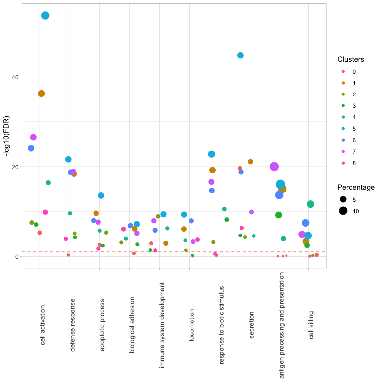

```r
go_vis_res1$plot
```

In addition to showing the enrichment in each category across the clusters, this plot also has the percentage of each categorical geneset overlapping with the cluster associated genes plotted onto the dot size, i.e. bigger dots mean that a more of the genes in a category are found in the cluster marker genes. Now taking the results generated the user can then choose different Parent term categories to plot using the **GO_viz_choose** function. To use this function the user provides the above results, either the marker data frame or a cluster gene list, and the categories they want ploted using the *chosen_cats* argument.

```r
## Take the results of the GO_visualization function and choose the categories to plot.
newcats<-names(sort(table(go_vis_res1$GO_sem$parentTerm)))[1:10]
newcats
```

```
#>  [1] "UV protection"
#>  [2] "astrocyte development"
#>  [3] "autocrine signaling"
#>  [4] "cell redox homeostasis"
#>  [5] "maintenance of location in cell"
#>  [6] "muscle adaptation"
#>  [7] "muscle contraction"
#>  [8] "myeloid leukocyte mediated immunity"
#>  [9] "protein refolding"
#> [10] "reactive nitrogen species metabolic process"
```

```r
go_vis_res2<-GO_viz_choose(go_vis_res1,chosen_cats=newcats,markers_df=markers, goterms=goterms)
```

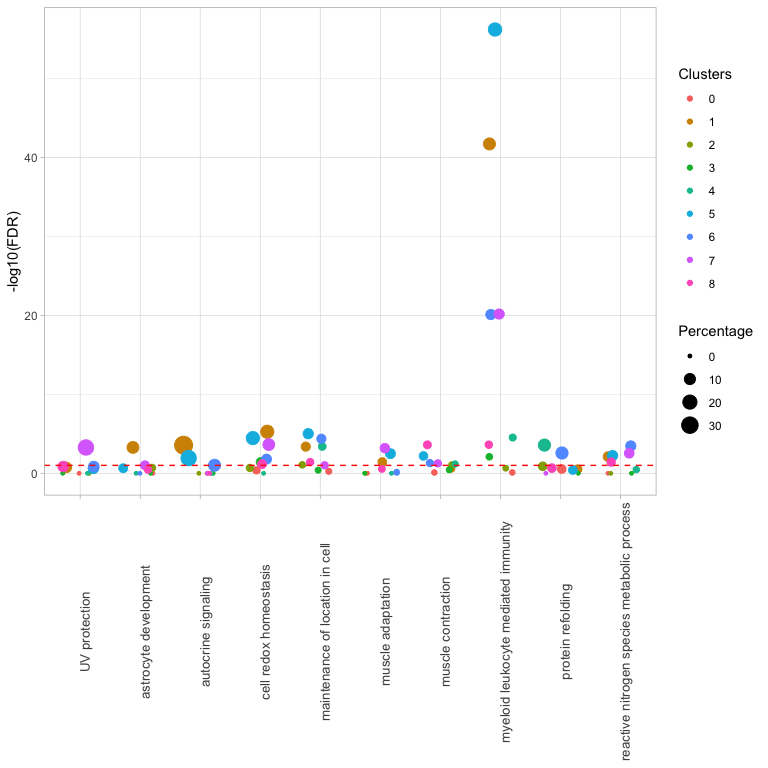

```r
go_vis_res2$plot
```

#### Visualizing the REACTOME Pathway enrichment

Next we will generate a graph for the REACTOME pathway enrichment analysis. The REACTOME pathways are organized in a hierarchial structure. To construct this graph requires two tab-delimited text files from the REACTOME database website (https://reactome.org/download-data). The first file is is titled “Pathways hierarchy relationship”, the second is the “Complete List of Pathways”. The package includes both of these files downloaded in November 2020. However, the user may download the files and use the **RPprep** function to prepare the “Complete List of Pathways” for use with this package. The RPprep function only has two arguments, the first is the “Complete List of Pathways” object and the second is *species* argument. One thing to keep in mind is that even after using the **RPprep** function some NAs may be within the data frame and need to be handled before continuing. For this example, I have downloaded the text file from the REACTOME database.

```r
## read in and prep the "Complete List of Pathways" file after downloading
## RP<-read.delim("ReactomePathways.txt",as.is=T,header=F)
## for this tutorial we will use the "Complete List of Pathways" file loaded as part of the package
data(RP)
RP<-RPprep(RP,"Homo sapiens")

## check for NAs before preceeding
which(is.na(RP))
```

```
#> integer(0)
```

```r
## read in the "Pathways hierarchy relationship" file after downloading
## RPR<-read.delim("ReactomePathwaysRelation.txt",as.is=T,header=F)
## for this tutorial we will use the "Pathways hierarchy relationship"  file loaded as part of the package
data(RPR)
```

Now that we have the two reacomte related objects we can preceede to the generating a graph. The **reactome_visualization** function will generate a graph with the REACTOME pathways grouped under the top level pathways in each tree and provides and overivew or summary of the enrichment results. You can remove the highest level pathways for a specific tree to arrange the pathways under the 2nd tier pathways. In the exaample below we will remove the top level pathway “Immune system” and group the pathways under the three 2nd tier terms; “Adaptive Immune System”, “Innate Immune System”, and “Cytokine Signaling in the Immune System”. This allows for some fine-tuning of the graph to reflect the cells in the experiment, in this case immune cells. To use the function the user must process the results object from the **enrich_test** function using the reactome_prep function.

```r
## this function requires the RP and RPR objects generated previously. We will first modify the RPR object by removing the Immune System nodes from the adjacency table. To do so you must obtain the pathway ID from the REACTOME database and remove rows where its in the first column
mRPR<-RPR[-(grep("R-HSA-168256",RPR[,1])),]
## Now we can use the reactome prep function
RP_ready<-reactome_prep(enrich_results$Enriched_df,RP=RP,RP_adj=mRPR)
head(RP_ready)
```

```
#>                                                                                                                                     label
#> REACTOME_EUKARYOTIC_TRANSLATION_ELONGATION                                                     REACTOME_EUKARYOTIC_TRANSLATION_ELONGATION
#> REACTOME_RESPONSE_OF_EIF2AK4_GCN2_TO_AMINO_ACID_DEFICIENCY                     REACTOME_RESPONSE_OF_EIF2AK4_GCN2_TO_AMINO_ACID_DEFICIENCY
#> REACTOME_EUKARYOTIC_TRANSLATION_INITIATION                                                     REACTOME_EUKARYOTIC_TRANSLATION_INITIATION
#> REACTOME_SRP_DEPENDENT_COTRANSLATIONAL_PROTEIN_TARGETING_TO_MEMBRANE REACTOME_SRP_DEPENDENT_COTRANSLATIONAL_PROTEIN_TARGETING_TO_MEMBRANE
#> REACTOME_NONSENSE_MEDIATED_DECAY_NMD                                                                 REACTOME_NONSENSE_MEDIATED_DECAY_NMD
#> REACTOME_SELENOAMINO_ACID_METABOLISM                                                                 REACTOME_SELENOAMINO_ACID_METABOLISM
#>                                                                          pval
#> REACTOME_EUKARYOTIC_TRANSLATION_ELONGATION                           3.6e-118
#> REACTOME_RESPONSE_OF_EIF2AK4_GCN2_TO_AMINO_ACID_DEFICIENCY           1.4e-109
#> REACTOME_EUKARYOTIC_TRANSLATION_INITIATION                           1.6e-106
#> REACTOME_SRP_DEPENDENT_COTRANSLATIONAL_PROTEIN_TARGETING_TO_MEMBRANE 5.2e-106
#> REACTOME_NONSENSE_MEDIATED_DECAY_NMD                                 4.0e-105
#> REACTOME_SELENOAMINO_ACID_METABOLISM                                 1.5e-104
#>                                                                           fdr
#> REACTOME_EUKARYOTIC_TRANSLATION_ELONGATION                           5.7e-115
#> REACTOME_RESPONSE_OF_EIF2AK4_GCN2_TO_AMINO_ACID_DEFICIENCY           1.1e-106
#> REACTOME_EUKARYOTIC_TRANSLATION_INITIATION                           8.3e-104
#> REACTOME_SRP_DEPENDENT_COTRANSLATIONAL_PROTEIN_TARGETING_TO_MEMBRANE 2.1e-103
#> REACTOME_NONSENSE_MEDIATED_DECAY_NMD                                 1.3e-102
#> REACTOME_SELENOAMINO_ACID_METABOLISM                                 4.0e-102
#>                                                                      signature
#> REACTOME_EUKARYOTIC_TRANSLATION_ELONGATION                                 118
#> REACTOME_RESPONSE_OF_EIF2AK4_GCN2_TO_AMINO_ACID_DEFICIENCY                 118
#> REACTOME_EUKARYOTIC_TRANSLATION_INITIATION                                 118
#> REACTOME_SRP_DEPENDENT_COTRANSLATIONAL_PROTEIN_TARGETING_TO_MEMBRANE       118
#> REACTOME_NONSENSE_MEDIATED_DECAY_NMD                                       118
#> REACTOME_SELENOAMINO_ACID_METABOLISM                                       118
#>                                                                      geneset
#> REACTOME_EUKARYOTIC_TRANSLATION_ELONGATION                                94
#> REACTOME_RESPONSE_OF_EIF2AK4_GCN2_TO_AMINO_ACID_DEFICIENCY               102
#> REACTOME_EUKARYOTIC_TRANSLATION_INITIATION                               120
#> REACTOME_SRP_DEPENDENT_COTRANSLATIONAL_PROTEIN_TARGETING_TO_MEMBRANE     113
#> REACTOME_NONSENSE_MEDIATED_DECAY_NMD                                     116
#> REACTOME_SELENOAMINO_ACID_METABOLISM                                     118
#>                                                                      overlap
#> REACTOME_EUKARYOTIC_TRANSLATION_ELONGATION                                59
#> REACTOME_RESPONSE_OF_EIF2AK4_GCN2_TO_AMINO_ACID_DEFICIENCY                57
#> REACTOME_EUKARYOTIC_TRANSLATION_INITIATION                                58
#> REACTOME_SRP_DEPENDENT_COTRANSLATIONAL_PROTEIN_TARGETING_TO_MEMBRANE      57
```

[output cut: 36 more lines]

```
#> REACTOME_SELENOAMINO_ACID_METABOLISM                                 R-HSA-2408522
#>                                                                           rootPath
#> REACTOME_EUKARYOTIC_TRANSLATION_ELONGATION                            R-HSA-392499
#> REACTOME_RESPONSE_OF_EIF2AK4_GCN2_TO_AMINO_ACID_DEFICIENCY           R-HSA-8953897
#> REACTOME_EUKARYOTIC_TRANSLATION_INITIATION                            R-HSA-392499
#> REACTOME_SRP_DEPENDENT_COTRANSLATIONAL_PROTEIN_TARGETING_TO_MEMBRANE  R-HSA-392499
#> REACTOME_NONSENSE_MEDIATED_DECAY_NMD                                 R-HSA-8953854
#> REACTOME_SELENOAMINO_ACID_METABOLISM                                 R-HSA-1430728
#>                                                                                                    rootName
#> REACTOME_EUKARYOTIC_TRANSLATION_ELONGATION                                           Metabolism of proteins
#> REACTOME_RESPONSE_OF_EIF2AK4_GCN2_TO_AMINO_ACID_DEFICIENCY           Cellular responses to external stimuli
#> REACTOME_EUKARYOTIC_TRANSLATION_INITIATION                                           Metabolism of proteins
#> REACTOME_SRP_DEPENDENT_COTRANSLATIONAL_PROTEIN_TARGETING_TO_MEMBRANE                 Metabolism of proteins
#> REACTOME_NONSENSE_MEDIATED_DECAY_NMD                                                      Metabolism of RNA
#> REACTOME_SELENOAMINO_ACID_METABOLISM                                                             Metabolism
```

The **reactome_visualization** function must be provided two objects, the RP_ready object and the mRPR objects previously generated. An additional argument *path_order*can also be supplied to set the order of pathways along the x-axis. This argument accepts a vector of pathway names from the rootName column of the RP_ready object and all names must be included. This function returns a list with two ojects, the plotting data frame and a ggplot2 object.

```r
react_vis1<-reactome_visualization(RP_ready,mRPR,RP=RP)
head(react_vis1$Plotting_dataframe)
```

```
#>                      Path Cluster P.N  percent   Tree.per  colors
#> 3   Developmental Biology       0   4 19.04762  6.6666667 #FF61C3
#> 5  Adaptive Immune System       0   3 14.28571 10.0000000 #FF61C3
#> 6              Metabolism       0   2  9.52381  0.6097561 #FF61C3
#> 11                Disease       0   2  9.52381  0.3289474 #FF61C3
#> 14 Metabolism of proteins       0   5 23.80952  4.0322581 #FF61C3
#> 21      Metabolism of RNA       0   3 14.28571  6.0000000 #FF61C3
```

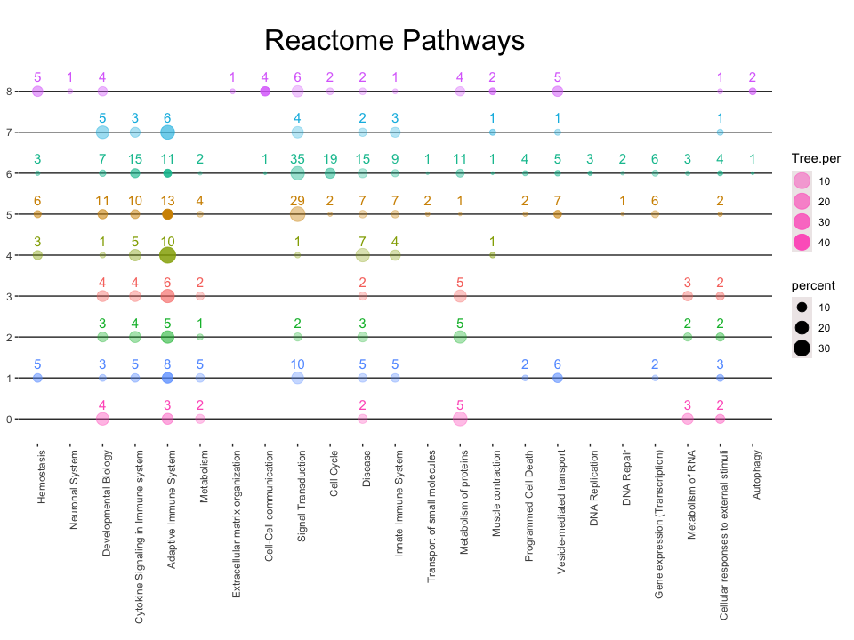

```r
react_vis1$plot_object
```

```r
## now we will generate the plot with the Pathways in alphabetical order
z<-sort(unique(RP_ready$rootName))
z
```

```
#>  [1] "Adaptive Immune System"
#>  [2] "Autophagy"
#>  [3] "Cell Cycle"
#>  [4] "Cell-Cell communication"
#>  [5] "Cellular responses to external stimuli"
#>  [6] "Cytokine Signaling in Immune system"
#>  [7] "DNA Repair"
#>  [8] "DNA Replication"
#>  [9] "Developmental Biology"
#> [10] "Disease"
#> [11] "Extracellular matrix organization"
#> [12] "Gene expression (Transcription)"
#> [13] "Hemostasis"
#> [14] "Innate Immune System"
#> [15] "Metabolism"
#> [16] "Metabolism of RNA"
#> [17] "Metabolism of proteins"
#> [18] "Muscle contraction"
#> [19] "Neuronal System"
#> [20] "Programmed Cell Death"
#> [21] "Signal Transduction"
#> [22] "Transport of small molecules"
#> [23] "Vesicle-mediated transport"
```

```r
react_vis2<-reactome_visualization(RP_ready,mRPR,RP=RP,path_order=z)
```

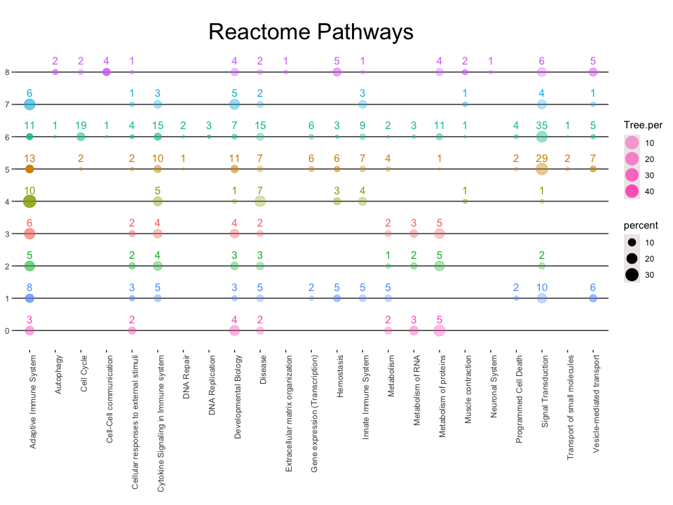

```r
react_vis2$plot_object
```

#### Conclusion

Both the **GO_visualization** and **reactome_visualization** functions generate ggplot2 objects which can be easily modified by users familiar with the ggpolt2 package. For users who are less experienced with ggplot2, the resultant plots can be tweaked using a program such as Adobe Illustrator. Each function also provides the data frame used to generate the plot which can easily be exported as a supplemental table for publication.